# What explains U.S. Covid-19 Vaccination Rates? A Machine Learning Workflow for County Level Ecological Inference

Rex W. Douglass

# The Outcome

Placebos - what other left hand side things can we put in there? Quote chadoins wto paper.

https://fivethirtyeight.com/features/the-extremes-of-the-gop-have-moved-beyond-fox-news/

https://www.prri.org/research/prri-ifyc-covid-vaccine-religion-report/

# Introduction

What explains vaccine uptake across counties in the US? The answer to this question has important implications for understanding and planning for the future course of the pandemic as pockets with low uptake become hotspots for future waves and especially future variants.

# Literature

https://www.medrxiv.org/content/10.1101/2021.05.28.21257946v1

https://www.cjonline.com/story/news/coronavirus/2021/02/19/kansas-plots-fix-problems-covid-19-vaccine-data-reporting/4507251001/

# Step 1: Form Reasonable Prior Beliefs

You may have seen [pairwise correlation plots](https://twitter.com/PollsAndVotes/status/1404667067392053248) that posit a data generating process of uptake like this.

Presidential vote is used in other projects attempting to estimate county level vaccination rates. (https://www.norc.org/PDFs/NIS/Seeskin_Estimating%20County%20Level%20Vaccination%20Coverage_2020.pdf)

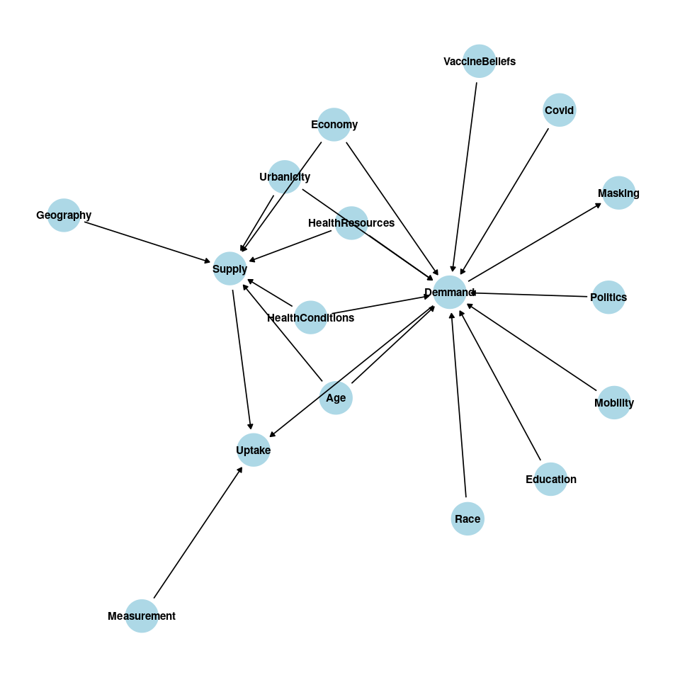

Others have [started to posit](https://tompepinsky.com/2021/06/24/trump-support-and-vaccination-rates-some-hypotheses-and-some-data/) a multivariate data generating process of vaccine uptake that is a linear function of a county’s demographic characteristics, urbanity, and recent presidential vote choices.

### Unit of Analysis

State vs County vs zip code

### The Vacination Process

Vaccinations began on December 14, 2020. https://www.hhs.gov/coronavirus/covid-19-vaccines/distribution/index.html

“The COVID-19 vaccine supply has increased to the point that DSHS will no longer allocate vaccine to providers each week. As of May 10, providers can order vaccine from DSHS on a daily basis. The tables on this page reflect allocations that were made between Dec. 14, 2020 – May 3,2021.” https://www.dshs.state.tx.us/coronavirus/immunize/vaccineallocations.aspx

Phase 1a Healthcare Personnel and Long-term care facility residents Phase 1b Frontline Essential workers, a>75 Phace 1c Persons aged 65-74, High Risk Medical Conditions Essential Workers

https://aspe.hhs.gov/system/files/pdf/265516/vaccine-administration-brief.pdf “As of February 22, 2021, the 50 states and D.C. had administered an average of 86.2% of their received vaccine doses. However, variability between states was considerable, with administration rates ranging from 72.9% (District of Columbia) to 99.8% (New Mexico).”

Many hypotheses have emerged to explain differences in vaccine administration rates between states.18,19 Potential predictors include state population size, size of the vaccine eligible population, centralization or decentralization of vaccine scheduling systems, vaccination site density, and local attitudes toward vaccines.

https://data.cdc.gov/Vaccinations/COVID-19-Vaccine-Distribution-Allocations-by-Juris/b7pe-5nws Vaccine allocations on a per-capita basis on relatively uniform, with the exception of outlying territories and Alaska because of transportation issues.

In sum, the simplest toy causal diagram is outside of the reach of a single linear model. Any individual parameter from a model fit to only a subset of these paths is not an estimate of the causal estimand. Further, there are only about 3000 counties worth the datapoints to disentangle this mess, and those counties are auto-correlated in lots of ways not taken into account here which further reduces the unique information available.

# Literature/RHS/ Data Generating Processes

We consider a data generating process for reported vaccine uptake that is a function of vaccine demand, vaccine supply, and institutional reporting mechanisms.

# Demand

The most proximate measure of demand available is survey self reported desire to receive a vaccine. COVID-19 Trends and Impact Survey (CTIS) run by the Delphi group at Carnegie Mellon (Barkay et al. 2020) We propose to measure demand most directly with survey questions of self reported desire for a vaccination.

(Truong et al. 2021)

(Pitts and Freeman 2021)

#### Combine Everything

### Summary Statistics

### Raw Data

# Step 4: Propose Features and a Credible Measurement Strategy

We divide features into groups: demography, politics, medical, education, and wealth. We then fit models over unique subsets of groups of features, 31 in total.

Multiple proxies for the same concept. Multiple measures of the same. Colinear.

# Step 5: Propose a Functional Search Space (Inductive Priors)

# Fit Models

#### Test Performance

# Step 7: Interpret Models

# Results

### The role of variables in the politics model

#### Interacts

### Interpreting Features

#### black_perc

#### black_perc

#### total_age65plus_perc

#### percent_of_adults_with_a_bachelors_degree_or_higher_2014_18

### The role of variables in the no politics model

## Look at Residuals

## Marginal Effects

## Interaction Effects

## Cluster Counties

# Step 8: Synthesize Competing Explainations

# Step 9: Unexplained Variation Remaining

# Conclusion

### Left Overs

Define some helper functions that will iterate over groups of variables and save predictions.

# Fit just a model without feature selection, fast as possible

# Left overs

#### BORTA VERSION

#### Validatoin Performance

# Step 6: Propose an Abblation and Interrogation Strategy

Given a model provides a certain level of performance, we want to go further and decompose that performance into explainable components related to features, hyperparameters, or other decisions. Feature ablation is the practice of removing access to features and gauging changes in model performance. The process isn’t straightforward. For starters, there are $2^k$ unique subsets of k features that we could select to hold out which is computationally infeasible. Second, different sets of features can have comparable average performance but different distributions across observations.

We consider three strategies. The first is theoretical, we group features by their stated or intended topic, e.g. TrumpVote2016 and TrumpVote2020 should be grouped because both literally measure votes and are intended to measure political preferences and behavior. The second is an appeal to unique bivariate information (correlation or mutual information), e.g. TrumpVote2016 and Percent With a Bachelor’s Degree should be grouped together because they tend to vary together and so might represent overlapping redundant information. The third is an appeal to the work they perform in explaining our specific outcome, e.g. TrumpVote2020 and PercentWhite should be group because conditioning on either produces similar shifts in predictions along with other known features.

Each of these strategies tells us something different about our model’s performance. The theoretically motivated strategy tells us about how the real world concepts relate to the outcome, but ignores the slippage between the values recorded and the latent real world concept it is intended to proxy for. The unique information strategy privileges heterogeneity, arranging features by how orthogonal they are in their original projections. That assumes the original projection was the right or a good one for our particular problem. The work motivated strategy is the other extreme, arranging features by their similarity within our specific modeling strategy. That assumes that our newly chosen projection is the right or a good one. The claim to validity here lies in our theoretical motivation of choice of model, buttressed by the demonstration of predictive performance.

Achen (2015), you can’t know a priori how a feature will be used by an algorithm. Even in OLS, you can’t ‘sign the bias’ by excluding a feature because its roll depends on the conditional correlation with the full rest of the feature vector. (green)

We can’t compute 2^n combinations of features, but we can generate a reasonably sized random sample. We fit 100k regression trees, of depth 6, each with a different random sample of 10 variables and a different random sample of 66% of the observations. We then calculate the shap values for each feature-interaction-observation combination, and we end up with a reasonable estimate of how our outcome variable variables in each subspace and how each pair of features work together to produce that result. We can then group features together based how similar the work is they do.

Marginal contribution

Conditional contribution

Barkay, Neta, Curtiss Cobb, Roee Eilat, Tal Galili, Daniel Haimovich, Sarah LaRocca, Katherine Morris, and Tal Sarig. 2020. “Weights and Methodology Brief for the COVID-19 Symptom Survey by University of Maryland and Carnegie Mellon University, in Partnership with Facebook.” *arXiv:2009.14675 [Cs]*, October. http://arxiv.org/abs/2009.14675.

Pitts, Peter J., and Emily Freeman. 2021. “Health Literacy: The Common Denominator of Healthcare Progress.” *The Patient - Patient-Centered Outcomes Research*, July. https://doi.org/10.1007/s40271-021-00537-9.

Truong, Judy, Simran Bakshi, Aghna Wasim, Mobeen Ahmad, and Umair Majid. 2021. “What Factors Promote Vaccine Hesitancy or Acceptance During Pandemics? A Systematic Review and Thematic Analysis.” *Health Promotion International*, no. daab105 (July). https://doi.org/10.1093/heapro/daab105.